# R Notebook

**4.4.3**

Failures in aircraft gas turbine engines due to high cycle fatigue is a pervasive problem. A single crystal nickel base superalloy was designed and manufactured to address this problem. We are interested in fitting a model to estimate mean cycles to failure from strain amplitude for turbine blades made of this new material.

The variables recorded are: *Strampl* strain amplitude *Cycfail* cycles to failure

From previous analyses, we suspect that a multiplicative relationship exists between the two variables.

|  | Cycfail | Strampl |
| --- | --- | --- |
| 1 | 1326 | 0.01495 |
| 2 | 1593 | 0.01470 |
| 3 | 4414 | 0.01100 |
| 4 | 5673 | 0.01190 |
| 5 | 29516 | 0.00873 |
| 6 | 26 | 0.01819 |

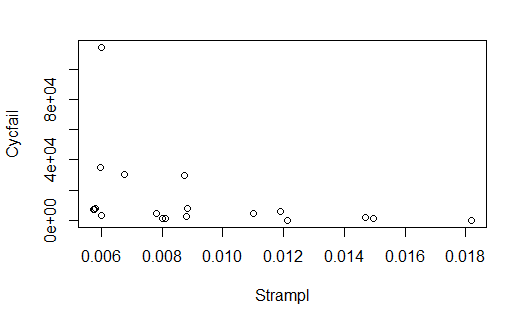

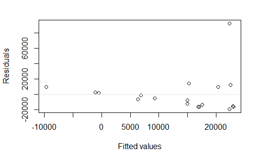

1. Explain briefly whether the first residual plot (eovcheck(gasturbines.lm)) confirms our suspicion that there might be a multiplicative relationship?

Ans: Yes because we see the fan effect in the residual plot.

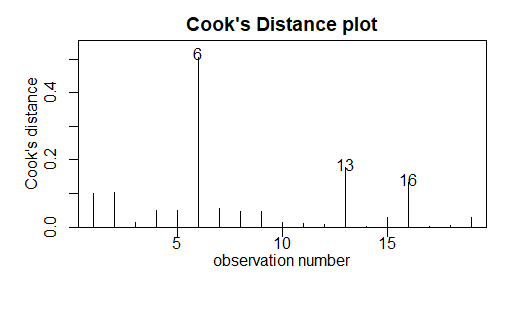

2. Does modcheck(gasturbines2.lm) show any issues with the model fitted?

Ans: Data point 6 has a Cook’s distance of more than 0.4. This data point appears to be significant.

```r
summary(gasturbines2.lm)
```

```
Call:
lm(formula = log(Cycfail) ~ Strampl, data = gasturbines.df)

Residuals:
    Min      1Q  Median      3Q     Max
-2.6971 -0.9876 -0.3975  1.1959  2.2105

Coefficients:
             Estimate Std. Error t value Pr(>|t|)
(Intercept)   11.7676     0.9359  12.574 4.91e-10 ***
Strampl     -387.8771    94.6997  -4.096 0.000753 ***
---
Signif. codes:  0 ‘***’ 0.001 ‘**’ 0.01 ‘*’ 0.05 ‘.’ 0.1 ‘ ’ 1

Residual standard error: 1.468 on 17 degrees of freedom
Multiple R-squared:  0.4967,    Adjusted R-squared:  0.4671
F-statistic: 16.78 on 1 and 17 DF,  p-value: 0.0007534
```

```r
gasturbines3.lm = lm(log(Cycfail)~Strampl, data = gasturbines.df[-6, ])
summary(gasturbines3.lm)
```

```
Call:
lm(formula = log(Cycfail) ~ Strampl, data = gasturbines.df[-6,
    ])

Residuals:
     Min       1Q   Median       3Q      Max
-3.07869 -0.53533  0.06447  1.02150  2.37065

Coefficients:
            Estimate Std. Error t value Pr(>|t|)
(Intercept)   11.076      1.063  10.418 1.55e-08 ***
Strampl     -299.357    115.522  -2.591   0.0197 *
---
Signif. codes:  0 ‘***’ 0.001 ‘**’ 0.01 ‘*’ 0.05 ‘.’ 0.1 ‘ ’ 1

Residual standard error: 1.441 on 16 degrees of freedom
Multiple R-squared:  0.2956,    Adjusted R-squared:  0.2516
F-statistic: 6.715 on 1 and 16 DF,  p-value: 0.01968
```

```r
cooks20x(gasturbines3.lm)
```

[output not shown]

```r
cooks.distance(gasturbines3.lm)
```

```
          1           2           3           4           5
0.052757986 0.065498733 0.009576105 0.047878472 0.050232719
          7           8           9          10          11
0.057763257 0.049253515 0.040570440 0.008147148 0.006887583
         12          13          14          15          16
0.004478001 0.391428216 0.002636036 0.042406796 0.173689969
         17          18          19
0.004565856 0.003665495 0.036512671
```

```r
summary(gasturbines3.lm)
```

```
Call:
lm(formula = log(Cycfail) ~ Strampl, data = gasturbines.df[-6,
    ])

Residuals:
     Min       1Q   Median       3Q      Max
-3.07869 -0.53533  0.06447  1.02150  2.37065

Coefficients:
            Estimate Std. Error t value Pr(>|t|)
(Intercept)   11.076      1.063  10.418 1.55e-08 ***
Strampl     -299.357    115.522  -2.591   0.0197 *
---
Signif. codes:  0 ‘***’ 0.001 ‘**’ 0.01 ‘*’ 0.05 ‘.’ 0.1 ‘ ’ 1

Residual standard error: 1.441 on 16 degrees of freedom
Multiple R-squared:  0.2956,    Adjusted R-squared:  0.2516
F-statistic: 6.715 on 1 and 16 DF,  p-value: 0.01968
```

4. Write down the equation of the final model fitted

Ans: log(Cycfaili) = meanStrampl + ei where ei ~ iid N(0, sd^2).

```r
100 * (exp(confint(gasturbines2.lm)) - 1)
```

```
              2.5 %   97.5 %
(Intercept) 1790863 92924196
Strampl        -100     -100
```

6. Write a brief Executive Summary of the main conclusions you would draw from the analysis.

7. Give a prediction for a single gas turbine’s cycles to failure for a strain amplitude of 0.01. Can we trust this prediction?

Reference: Arakere N. K., Swanson G. G. (2000) Effect of Crystal Orientation on Fatigue Failure of Single Crystal Nickel Base Turbine Blade Superalloys. ASME. J. Eng. Gas Turbines Power. 124(1):161-176. Devore, J. L. (2016). Probability and Statistics for Engineering and the Sciences, 9e. Boston, MA: Cengage Learning.